# Deep learning enables accurate clustering with batch effect removal in single-cell RNA-seq analysis

## Memory useage and running time for 1.3 millon mouse

```r
load("time_memory_new.RData")
colnames(time_final)[1]="time_consume"
```

```r
time_final$methods=factor(time_final$methods,levels=c("DESC","DESC_GPU","DESC_multicpu","scVI","scVI_GPU","scVI_multicpu","Seurat3.0"),
                         labels=c("DESC","DESC_GPU","DESC_multicpu","scVI","scVI_GPU","scVI_multicpu","Seurat3.0"))
df_time=time_final
tmp=as.character(df_time$samplesize)
tmp[tmp=="all"]=1.3e6
df_time$samplesize=as.integer(tmp)
#df_time=subset(df_time,select=names(table(df_time$methods))[names(table(df_time$methods))%in%])
```

```r
df0=aggregate(mem_final,by = list(paste0(as.character(mem_final$methods),mem_final$samplesize)),FUN=max)
tmp=as.character(df0$samplesize)
tmp[tmp=="all"]=1.3e6
df0$samplesize=as.integer(tmp)
```

```r
dfnew_time=subset(df_time,select = c("time_consume","methods","samplesize"))
dfnew_time$time_consume=as.numeric(dfnew_time$time_consume)
tmp=dfnew_time$methods
dfnew_time$methods=factor(tmp)
dfnew_time$samplesize.norm=dfnew_time$samplesize
#prettyNum(c(123,1234),big.mark=",", preserve.width="none")# preserve width
dfnew_time$samplesize=factor(format(as.numeric(as.character(dfnew_time$samplesize.norm)),big.mark=",", preserve.width="none"))
colors_use=color_celltype[1:length(levels(dfnew_time$methods))]
names(colors_use)=levels(dfnew_time$methods)
```

```r
p=ggplot(data=dfnew_time,aes(x=factor(samplesize),y=time_consume,fill=methods,width=0.85))+
  geom_bar(position= position_dodge(width = 0.85,preserve = "single"),stat="identity")+
  xlab("Number of cells")+
  ylab("Time (seconds)")+
  scale_y_continuous(expand = c(0,0,0.05,0),labels=comma)+
  theme(axis.text.x = element_text(angle=30,hjust=1))
p=p+ggtitle("")+scale_fill_manual(values=colors_use)+
  theme(legend.key.size = unit(0.6,"cm"))
p_time=p+theme(legend.position = c(0.35,0.78))
#p_time
#save_plot(filename = "~/figure3/fig3h_horizontal.pdf",p+theme_mem+theme(legend.key.size = unit(1.2,"cm"))+theme(legend.position ="none"),base_height = 11,base_width = 18)
```

```r
df0=aggregate(mem_final,by = list(paste0(mem_final$methods,mem_final$samplesize)),FUN=max)
df0=subset(df0,select = c("memory_use","methods","samplesize"))
df0$methods=factor(df0$methods,levels=c("DESC","DESC_GPU","DESC_multicpu","scVI","scVI_GPU","scVI_multicpu","Seurat3.0"),
                         labels=c("DESC","DESC_GPU","DESC_multicpu","scVI","scVI_GPU","scVI_multicpu","Seurat3.0"))
tmp=as.character(df0$samplesize)
tmp[tmp=="all"]=1.3e6
df0$samplesize=as.integer(tmp)

df0$samplesize.norm=df0$samplesize
df0$samplesize=factor(format(as.numeric(as.character(df0$samplesize.norm)),big.mark=",", preserve.width="none"))
colors_use=color_celltype[1:length(levels(df0$methods))]
names(colors_use)=levels(df0$methods)
```

```r
p=ggplot(data=df0,aes(x=factor(samplesize),y=memory_use,fill=methods,width=0.85))+
  geom_bar(position= position_dodge(width = 0.9,preserve = "single"),stat="identity")+xlab("Number of cells")+ylab("Memory (GB)")+scale_y_continuous(expand = c(0,0,0.05,0),labels=comma)+theme(axis.text.x = element_text(angle=30,hjust=1))
p=p+ggtitle("")+scale_fill_manual(values=colors_use)+theme(legend.key.size = unit(0.6,"cm"))
p_mem=p+theme(legend.position = c(0.65,0.78))
#p_mem
#save_plot(filename = "~/figure3/fig3I_horizontal.pdf",p+theme_mem+theme(legend.key.size = unit(1.2,"cm"))+theme(legend.position ="none"),base_height = 11,base_width = 18)
```

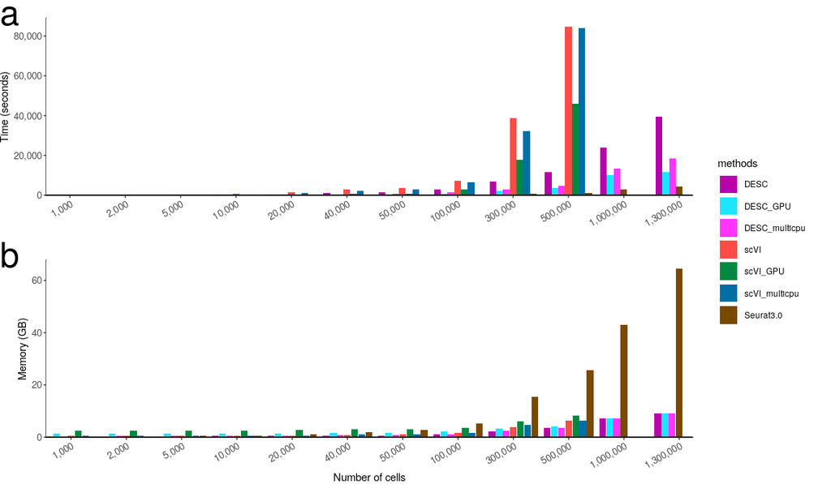

```r
p=egg::ggarrange(p_time+scale_x_discrete(expand = c(0.02,0.02))+theme(axis.text = element_text(size=10))+
                   theme(legend.position = "none",plot.margin =unit(c(0,0,0,0),"cm"))+xlab(""),
                 p_mem+scale_x_discrete(expand = c(0.02,0.02))+theme(axis.text = element_text(size=10))+
                   theme(legend.position = "none",plot.margin =unit(c(0,0,0,0),"cm")),ncol=1,draw=F,
                 labels = c("a","b"),
                       label.args = list(gp = grid::gpar(cex =3,color="black",face="bold")))

p_legend=get_legend(p_time+theme(legend.position = "top")+
                      guides(fill = guide_legend(override.aes = list(alpha = 1, size=8),ncol=1,title.position="top")))
p0=grid.arrange(p,p_legend,ncol=2,widths=c(5,1),newpage = F)
```

```r
#ggsave("~/Documents/DESC_paper_prepare/DESC_paper_v3/figures/figure_main/memory_time.tiff",p0,width=12,height = 7,dpi=120)
```

# `Supplementary Figure 17

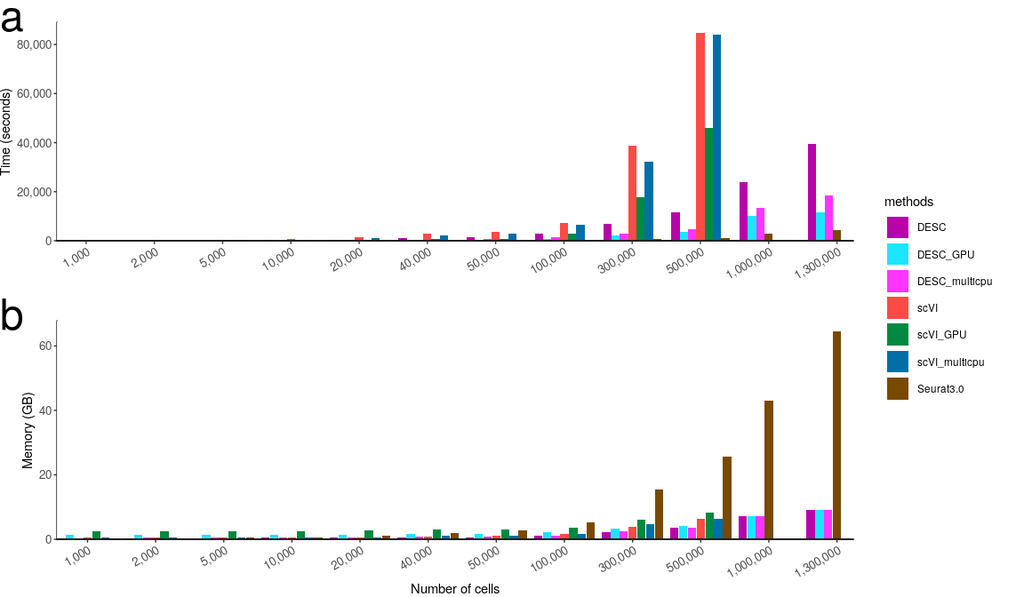

```r
##Supplementary Figure 17
ggsave(file.path(fig_path,"Figure.S17.tiff"),plot_grid(p0),width=12,height = 7,dpi=300,compression="lzw")
ggsave(file.path(fig_path,"Figure.S17.pdf"),plot_grid(p0),width=12,height = 7,dpi=300)
plot_grid(p0)
```

**Suplementary Fig 17**. Comparison of running time (a) and memory usage (b) of three clustering method for datasets with various numbers of cells, which were randomly sampled from the 1.3 million mouse brain dataset. DESC: used a single CPU; DESC_GPU: used a single GPU; DESC_multicpu: used 10 CPUs; ScVI: used a single CPU. scVI_GPU: used a single GPU; scVI_multicpu: used 10 CPUs. DESC used desc.train function in python module desc with version 1.0.0.5. Seurat used FindClusters function in R package Seurat version 2.3.4. Seurat3.0 used FindClusters function in R package Seurat version 3.0.0. scVI used UnsupervisedTrainer function in python module scvi version 0.3.0. Remark: we analyzed this dataset on Ubuntu 16.04.4 LTS with Intel(R) Xeon(R) CPU E5-2620 v4 @ 2.10GHz and 128GB memory.

All data analyses reported in this paper were conducted on Ubuntu 18.04.1 LTS with Intel® Core (TM) i7-8700K CPU @ 3.70GHz and 64GB memory, except for the 1.3 million cells mouse brain data. For the 1.3 million cells mouse brain dataset, we analyzed on Ubuntu 16.04.4 LTS with Intel(R) Xeon(R) CPU E5-2620 v4 @ 2.10GHz and total 128GB memory.

# Running time and memory useage and for different number of batches

## The number of Batches is 2

```r
env=new.env()
load("../memory_compare_DESC/time_memory_new.RData",envir = env)
mem_final=env$mem_final
time_final=env$time_final
colnames(time_final)[1]="time_consume"
```

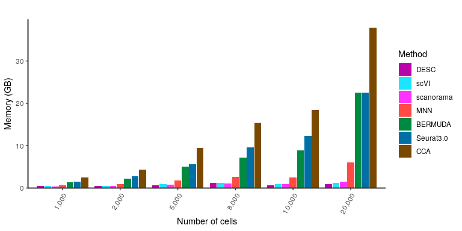

```r
df_time=time_final
df0=aggregate(mem_final,by = list(paste0(mem_final$methods,mem_final$samplesize)),FUN=max)
df0$Method=plyr::mapvalues(df0$methods,from=c("desc","cca3.0","cca","mnn","scVI","bermuda","scanorama"),
                           to=c("DESC","Seurat3.0","CCA","MNN","scVI","BERMUDA","scanorama"))
df0$Method=factor(df0$Method,levels=c("DESC","scVI","scanorama","MNN","BERMUDA","Seurat3.0","CCA"))
colors_use=color_celltype[1:length(levels(df0$Method))]
names(colors_use)=levels(df0$Method)
#df0$samplesize=factor(df0$samplesize,levels =sort(as.numeric(unique(df0$samplesize))))
df0$samplesize=factor(format(as.numeric(as.character(df0$samplesize)),big.mark=",", preserve.width="none"))
p=ggplot(data=df0,aes(x=factor(samplesize),y=memory_use,fill=Method,width=0.85))+
  geom_bar(position= position_dodge(width = 0.9,preserve = "single"),stat="identity")+
  xlab("Number of cells")+
  ylab("Memory (GB)")+
  scale_y_continuous(expand = c(0,0,0.05,0),labels=scales::comma)+
  theme(axis.text.x = element_text(angle=60,hjust=1))+
  ggtitle("")+
  scale_fill_manual(values=colors_use)+
  theme(legend.key.size = unit(0.6,"cm"))
#p_mem=p+theme(legend.position = c(0.65,0.78))
p_mem_batch2=p+theme(legend.position="right")
p_mem_batch2
```

# Figure 10 (right)

```r
df_time=time_final
df0=aggregate(mem_final,by = list(paste0(mem_final$methods,mem_final$samplesize)),FUN=max)
df0$Method=plyr::mapvalues(df0$methods,from=c("desc","cca3.0","cca","mnn","scVI","bermuda","scanorama"),
                           to=c("DESC","Seurat3.0","CCA","MNN","scVI","BERMUDA","scanorama"))
df0$Method=factor(df0$Method,levels=c("DESC","scVI","scanorama","MNN","BERMUDA","Seurat3.0","CCA"))
colors_use=color_celltype[1:length(levels(df0$Method))]
names(colors_use)=levels(df0$Method)
#df0$samplesize=factor(df0$samplesize,levels =sort(as.numeric(unique(df0$samplesize))))
df0$samplesize=factor(format(as.numeric(as.character(df0$samplesize)),big.mark=",", preserve.width="none"))
p=ggplot()+
  geom_bar(data=df0,aes(x=Method,y=memory_use,group=factor(samplesize),fill=Method),
           width=0.7,
           position= position_dodge(width = 0.8,preserve = "single"),stat="identity")+
  xlab("Number of cells")+
  ylab("Memory (GB)")+
  scale_y_continuous(expand = c(0,0,0.05,0),labels=scales::comma,position = "left",breaks = c(0,10,20,30,40),limits = c(0,40))+
  scale_x_discrete(expand=c(0,0,0,0))+
  theme(axis.text.x = element_text(angle=60,hjust=1))+
  theme(axis.title.y = element_text(angle=-90,hjust=0.5))+
  geom_text(aes(x=1,y=c(10,20,30,40)-1,label=c("10GB","20GB","30GB","40GB")))+
  ggtitle("")+
  scale_fill_manual(values=colors_use,guide=F)+
  theme(legend.key.size = unit(0.6,"cm"))
#p_mem=p+theme(legend.position = c(0.65,0.78))
pp=p+theme(legend.position="none")+xlab("")+theme_void()+
  theme( panel.grid.major.y = element_line(size=0.3,linetype = "dotted"))
```

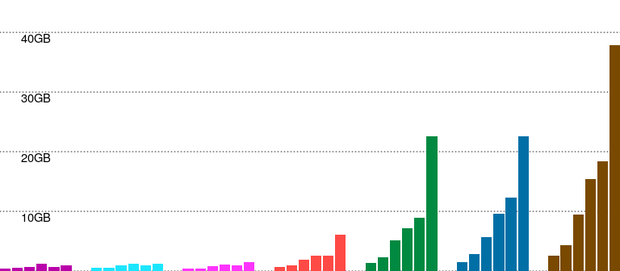

```r
# Figure 10 (right)
ggsave(file.path(fig_path,"Figure.10.right.pdf"),pp,width = 8,height = 3.5,dpi=300)
ggsave(file.path(fig_path,"Figure.10.right.tiff"),pp,width = 8,height = 3.5,dpi=300,compression="lzw")
pp
```

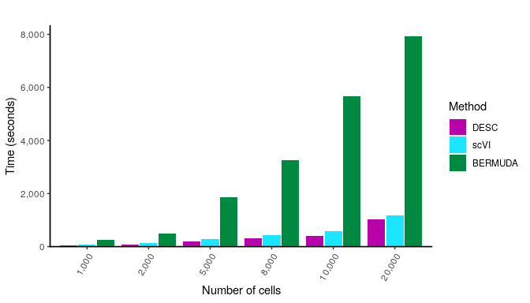

```r
dfnew_time=subset(df_time,select = c("time_consume","methods","samplesize"))
dfnew_time$time_consume=as.numeric(dfnew_time$time_consume)
dfnew_time$samplesize.norm=dfnew_time$samplesize
dfnew_time$Method=plyr::mapvalues(dfnew_time$methods,from=c("desc","cca3.0","cca","mnn","scVI","bermuda","scanorama"),
                                  to=c("DESC","Seurat3.0","CCA","MNN","scVI","BERMUDA","scanorama"))
dfnew_time$Method=factor(dfnew_time$Method,levels=c("DESC","scVI","scanorama","MNN","BERMUDA","Seurat3.0","CCA"))
dfnew_time0=subset(dfnew_time,dfnew_time$Method%in%c("DESC","scVI","BERMUDA"))
#prettyNum(c(123,1234),big.mark=",", preserve.width="none")# preserve width
dfnew_time0$samplesize=factor(format(as.numeric(as.character(dfnew_time0$samplesize.norm)),big.mark=",", preserve.width="none"))
colors_use=color_celltype[c(1:length(levels(df0$Method)))]
names(colors_use)=levels(dfnew_time0$Method)

p_descscvi_2=ggplot(data=dfnew_time0,aes(x=factor(samplesize),y=time_consume,fill=Method,width=0.85))+
  geom_bar(position= position_dodge(width = 0.9,preserve = "single"),stat="identity")+
  xlab("Number of cells")+
  ylab("Time (seconds)")+
  scale_y_continuous(expand = c(0,0,0.05,0.),labels=scales::comma)+
  theme(axis.text.x = element_text(hjust=1,angle=60))+
  ggtitle("")+
  scale_fill_manual(values=colors_use)+
  theme(legend.key.size = unit(0.6,"cm"))+
  theme(legend.position = "right")
p_descscvi_2
```

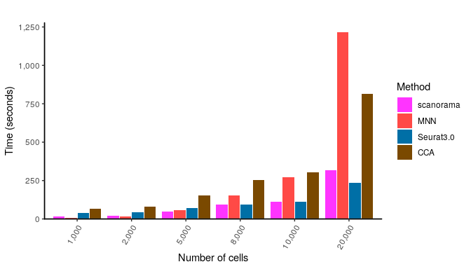

```r
dfnew_time=subset(df_time,select = c("time_consume","methods","samplesize"))
dfnew_time$time_consume=as.numeric(dfnew_time$time_consume)
dfnew_time$samplesize.norm=dfnew_time$samplesize
dfnew_time$Method=plyr::mapvalues(dfnew_time$methods,from=c("desc","cca3.0","cca","mnn","scVI","bermuda","scanorama"),
                                  to=c("DESC","Seurat3.0","CCA","MNN","scVI","BERMUDA","scanorama"))
dfnew_time$Method=factor(dfnew_time$Method,levels=c("DESC","scVI","scanorama","MNN","BERMUDA","Seurat3.0","CCA"))
dfnew_time0=subset(dfnew_time,!dfnew_time$Method%in%c("DESC","scVI","BERMUDA"))


#prettyNum(c(123,1234),big.mark=",", preserve.width="none")# preserve width
dfnew_time0$samplesize=factor(format(as.numeric(as.character(dfnew_time0$samplesize.norm)),big.mark=",", preserve.width="none"))
colors_use=color_celltype[c(1:length(levels(df0$Method)))]
names(colors_use)=levels(dfnew_time0$Method)

p_other_2=ggplot(data=dfnew_time0,aes(x=factor(samplesize),y=time_consume,fill=Method,width=0.85))+
  geom_bar(position= position_dodge(width = 0.9,preserve = "single"),stat="identity")+
  xlab("Number of cells")+
  ylab("Time (seconds)")+
  scale_y_continuous(expand = c(0,0,0.05,0),labels=scales::comma)+
  theme(axis.text.x = element_text(hjust=1,angle=60))+
  ggtitle("")+
  scale_fill_manual(values=colors_use)+
  theme(legend.key.size = unit(0.6,"cm"))+
  theme(legend.position = "right")
p_other_2
```

## The number of Batches is 4

```r
env2=new.env()
load("../memory_compare_DESC2/time_memory_new.RData",envir = env2)
time_final=env2$time_final
mem_final=env2$mem_final
colnames(time_final)[1]="time_consume"
```

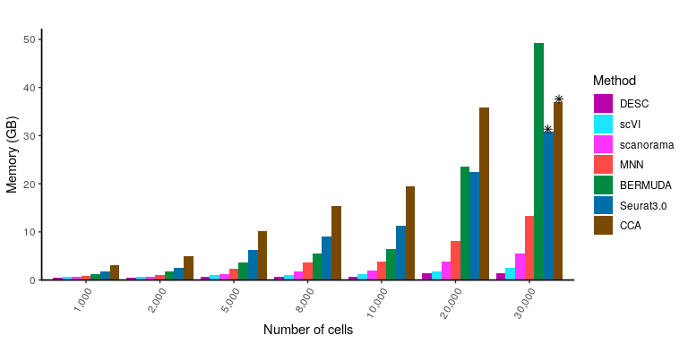

```r
df_time=time_final
df0=aggregate(mem_final,by = list(paste0(mem_final$methods,mem_final$samplesize)),FUN=max)
df0$Method=plyr::mapvalues(df0$methods,from=c("desc","cca3.0","cca","mnn","scVI","bermuda","scanorama"),
                           to=c("DESC","Seurat3.0","CCA","MNN","scVI","BERMUDA","scanorama"))
df0$Method=factor(df0$Method,levels=c("DESC","scVI","scanorama","MNN","BERMUDA","Seurat3.0","CCA"))

colors_use=color_celltype[1:length(levels(df0$Method))]
names(colors_use)=levels(df0$Method)
#df0$samplesize=factor(df0$samplesize,levels =sort(as.numeric(unique(df0$samplesize))))
df0$samplesize=factor(format(as.numeric(as.character(df0$samplesize)),big.mark=",", preserve.width="none"))
p=ggplot(width=0.85)+
  geom_bar(data=df0,aes(x=factor(samplesize),y=memory_use,fill=Method),
                        position= position_dodge(width = 0.9,preserve = "single"),stat="identity")+
  xlab("Number of cells")+
  ylab("Memory (GB)")+
  scale_y_continuous(expand = c(0,0),labels=scales::comma,limits = c(0,1.06*max(df0$memory_use)))+
  theme(axis.text.x = element_text(angle=60,hjust=1))+
  ggtitle("")+
  scale_fill_manual(values=colors_use)+
  theme(legend.key.size = unit(0.6,"cm"))+
  geom_point(aes(x=7.4,y=df0$memory_use[grep(x=df0$Group.1,pattern = "cca30000")]*1.02),shape=8,size=2)+
  geom_point(aes(x=7.25,y=df0$memory_use[grep(x=df0$Group.1,pattern = "cca3.030000")]*1.02),shape=8,size=2)
#p_mem=p+theme(legend.position = c(0.65,0.78))
p_mem_batch4=p+theme(legend.position="right")
p_mem_batch4
```

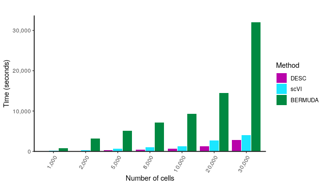

```r
dfnew_time=subset(df_time,select = c("time_consume","methods","samplesize"))
dfnew_time$time_consume=as.numeric(dfnew_time$time_consume)
dfnew_time$samplesize.norm=dfnew_time$samplesize
dfnew_time$Method=plyr::mapvalues(dfnew_time$methods,from=c("desc","cca3.0","cca","mnn","scVI","bermuda","scanorama"),
                                  to=c("DESC","Seurat3.0","CCA","MNN","scVI","BERMUDA","scanorama"))
dfnew_time$Method=factor(dfnew_time$Method,levels=c("DESC","scVI","scanorama","MNN","BERMUDA","Seurat3.0","CCA"))
dfnew_time0=subset(dfnew_time,dfnew_time$Method%in%c("DESC","scVI","BERMUDA"))

#prettyNum(c(123,1234),big.mark=",", preserve.width="none")# preserve width
dfnew_time0$samplesize=factor(format(as.numeric(as.character(dfnew_time0$samplesize.norm)),big.mark=",", preserve.width="none"))
colors_use=color_celltype[1:length(levels(dfnew_time0$Method))]
names(colors_use)=levels(dfnew_time0$Method)

p_descscvi_4=ggplot(data=dfnew_time0,aes(x=factor(samplesize),y=time_consume,fill=Method,width=0.85))+
  geom_bar(position= position_dodge(width = 0.9,preserve = "single"),stat="identity")+
  xlab("Number of cells")+
  ylab("Time (seconds)")+
  scale_y_continuous(expand = c(0,0,0.05,0),labels=scales::comma)+
  theme(axis.text.x = element_text(hjust=1,angle=60))+
  ggtitle("")+
  scale_fill_manual(values=colors_use)+
  theme(legend.key.size = unit(0.6,"cm"))+
  theme(legend.position = "right")
p_descscvi_4
```

```r
dfnew_time=subset(df_time,select = c("time_consume","methods","samplesize"))
dfnew_time$time_consume=as.numeric(dfnew_time$time_consume)
dfnew_time$samplesize.norm=dfnew_time$samplesize
dfnew_time$Method=plyr::mapvalues(dfnew_time$methods,from=c("desc","cca3.0","cca","mnn","scVI","bermuda","scanorama"),
                                  to=c("DESC","Seurat3.0","CCA","MNN","scVI","BERMUDA","scanorama"))
dfnew_time$Method=factor(dfnew_time$Method,levels=c("DESC","scVI","scanorama","MNN","BERMUDA","Seurat3.0","CCA"))
dfnew_time0=subset(dfnew_time,!dfnew_time$Method%in%c("DESC","scVI","BERMUDA"))

dfnew_time0$samplesize=factor(format(as.numeric(as.character(dfnew_time0$samplesize.norm)),big.mark=",", preserve.width="none"))
colors_use=color_celltype[1:length(levels(dfnew_time0$Method))]
names(colors_use)=levels(dfnew_time0$Method)

p_other_4=ggplot(width=0.85)+
  geom_bar(data=dfnew_time0,aes(x=factor(samplesize),y=time_consume,fill=Method),
                                position= position_dodge(width = 0.9,preserve = "single"),stat="identity")+
  xlab("Number of cells")+
  ylab("Time (seconds)")+
  scale_y_continuous(expand = c(0,0),labels=scales::comma,limits=c(0,1.03*max(dfnew_time0$time_consume)))+
  theme(axis.text.x = element_text(hjust=1,angle=60))+
  ggtitle("")+
  scale_fill_manual(values=colors_use)+
  theme(legend.key.size = unit(0.6,"cm"))+
  theme(legend.position = "right")+
  geom_point(aes(x=7.34,y=dfnew_time0$time_consume[grep(x=rownames(dfnew_time0),pattern = "cca_30000")]*1.02),shape=8,size=2)+
  geom_point(aes(x=7.1,y=dfnew_time0$time_consume[grep(x=rownames(dfnew_time0),pattern = "cca3.0_30000")]*1.02),shape=8,size=2)
p_other_4=p_other_4+theme(legend.position = "right")
```

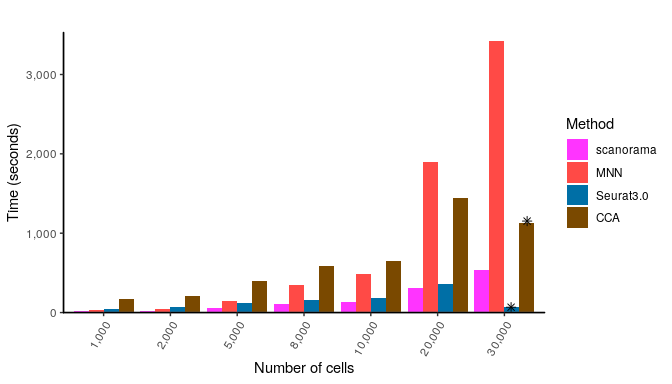

```r
p_other_4
```

```r
#tiff("~/Documents/DESC_paper_prepare/DESC_paper_v2/figures/figure_supp/memory_time_other_batch4.tiff",width=0.7*800,height = 0.67*400)
#p_other_4
#dev.off()
```

## The number of Batches is 30

```r
env2=new.env()
load("../memory_compare_DESC3/time_memory_new.RData",envir = env2)
time_final=env2$time_final
mem_final=env2$mem_final
colnames(time_final)[1]="time_consume"
```

```r
p1=p_descscvi_30+coord_cartesian(ylim = c(0,49000))+theme(plot.margin = unit(c(0,0,0,0),"cm"))+
  theme(axis.title.y = element_text(hjust=1))
p2=p_descscvi_30+coord_cartesian(ylim = c(50000,150000))+
  theme(axis.text.x = element_blank(),
        plot.margin = unit(c(0,0,-0.6,0),"cm"),
        axis.ticks.x =element_blank(),
        axis.title.x = element_blank(),
        legend.position = "none",
        axis.line.x=element_blank())+ylab("")+xlab("")+scale_y_continuous(breaks = c(50000,100000,150000),labels =scales::comma)
p=egg::ggarrange(p2,p1,ncol=1,heights=c(1,3),draw = F)
```

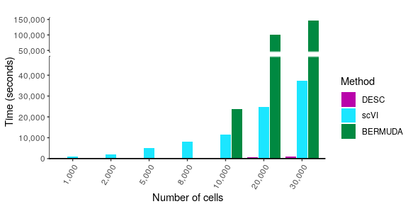

```r
#ggsave("~/Documents/DESC_paper_prepare/DESC_paper_v3/figures/figure_main/memory_time_add_2.tiff",p,width=5,height=3,dpi=300)
p
```

```r
p_final=egg::ggarrange(p_mem_batch2+theme(axis.text = element_text(size=10)),
                       p_descscvi_2+theme(axis.text = element_text(size=10)),
                       p_other_2+theme(axis.text = element_text(size=10)),
                       p_mem_batch4+theme(axis.text = element_text(size=10)),
                       p_descscvi_4+theme(axis.text = element_text(size=10)),
                       p_other_4+theme(axis.text = element_text(size=10)),
                       p_mem_batch30+theme(axis.text = element_text(size=10))+theme(plot.margin = unit(c(2,0,0,0),"cm")),
                       #p_descscvi_30+theme(axis.text = element_text(size=10)),
                       ggplot()+theme_void(),
                       p_other_30+theme(axis.text = element_text(size=10)),
                       ncol=3,draw=F)
                       #labels = c("a","","","b","","","c","",""),
                       #label.args = list(gp = grid::gpar(font = 4, cex =2.5,color="darkblue",face="bold")))
```

```r
#ggsave("~/Documents/DESC_paper_prepare/DESC_paper_v3/figures/figure_main/memory_time_add.tiff",p_final,width=18,height=11,dpi=300)
#ggsave("~/Documents/DESC_paper_prepare/DESC_paper_v3/figures/figure_main/memory_time_add.pdf",p_final,width=18,height=11)
```

```r
p_final=egg::ggarrange(p_mem_batch2+theme(axis.text = element_text(size=10)),
                       p_descscvi_2+theme(axis.text = element_text(size=10)),
                       p_other_2+theme(axis.text = element_text(size=10)),
                       p_mem_batch4+theme(axis.text = element_text(size=10)),
                       p_descscvi_4+theme(axis.text = element_text(size=10)),
                       p_other_4+theme(axis.text = element_text(size=10)),
                       p_mem_batch30+theme(axis.text = element_text(size=10))+theme(plot.margin = unit(c(2,0,0,0),"cm")),
                       #p_descscvi_30+theme(axis.text = element_text(size=10)),
                       ggplot()+theme_void(),
                       p_other_30+theme(axis.text = element_text(size=10)),
                       ncol=3,draw=F,
                       labels = c("a","b","c","d","e","f","g","h","i"),
                       label.args = list(gp = grid::gpar( cex =3.5,color="black",face="bold")))
```

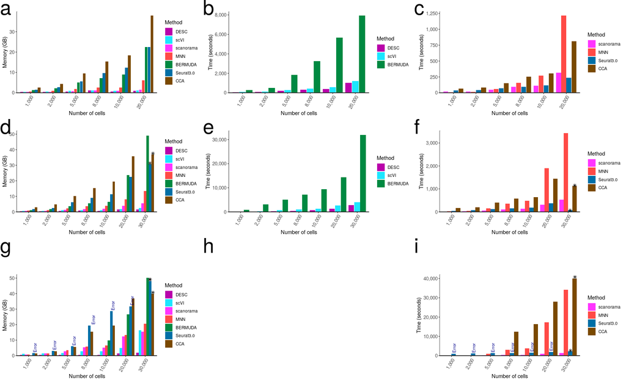

```r
p_final
```

```r
options(device = cairo_pdf)
pp=ggdraw() +
  draw_plot(p_final, x=0, y=0, width=1, height = 1)+
  draw_plot(p, x=0.33, y=0, width=0.33, height = 0.31)
```